# Analysis of Environmental Data

Probability and Frequentist Concepts

Michael France Nelson

Fall 2021

# Learning Objectives

- Use the distribution functions in R.
- Sampling distribution insight

# Seeing Theory

You’ll be using the [**Seeing Theory**](https://seeing-theory.brown.edu/index.html) site to practice help with graphical intuition of Frequentist concepts.

It’s a fantastic site, and I encourage you to check out the parts that we won’t cover in this assignment.

# Distribution functions for discrete distributions

R implements probability, cumulative probability, and quantile functions for many *parametric* distributions.

The naming convention is to use the name, or an abbreviation, of the distribution preceded by a prefix. For example with the *binomial* distribution the functions are:

dbinom: the probability mass function

pbinom: the cumulative mass function

qbinom: the quantile function

- Remember that discrete distributions use the term *mass* rather than *density*.
- Remember that each distribution has different parameters, and you’ll have to look at the documentation on how to specify them with the probability functions.

> For a *discrete* parametric distribution, the distribution functions allow you to ask the following questions:
1. What is the probability that I observe a value of **exactly** $x$?: The probability mass function, e.g. `dbinom()`
2. What is the probability that I observe a value of $x$ *or less*?: The cumulative mass function, e.g. `pbinom()`
3. What is the probability that I observe a value of $x$ *or more*?: The cumulative mass function, e.g. `pbinom()`
4. What is the *median* or 50<sup>th</sup> percentile?: The quantile function, e.g. `qbinom()`
5. What is the 90<sup>th</sup> percentile?: The quantile function, e.g. `qbinom()`

# Distribution functions for continuous distributions

The naming convention is the same as for discrete distributions. For example with the *normal* distribution the functions are:

dnorm: the probability density function

pnorm: the cumulative density function

qnorm: the quantile function

- Remember that continuous distributions use the term *density* rather than *mass*.
- Remember that each distribution has different parameters, and you’ll have to look at the documentation on how to specify them with the probability functions.

> For a *continuous* parametric distribution, the distribution functions allow you to ask the following questions:
1. Is a value of 1.2 or 2.4 more likely? - The probability density function, e.g. `dnorm()`
2. What is the probability that I observe a value between 1.2 and 2.4?: The cumulative density function, e.g. `pnorm()`
3. What is the probability that I observe a value of 1.3 or more?: The cumulative density function, e.g. `pnorm()`
4. What is the probability that I observe a value of 2.4 or less?: The cumulative density function, e.g. `pnorm()`
5. What is the 20<sup>th</sup> percentile of fish lengths?: The quantile function, e.g. `qnorm()`

# The law of total probability

You can use R’s distribution functions to answer many probability questions, but sometimes you have to be creative and use them in combinations.

> The sum of all events in the sample space is 1.0.

Sometimes it’s easier to calculate the probability of the *complement* of an event, rather than the event’s probability directly.

Suppose you have an event $E$

The *complement* of an event $E^c$ is just the rest of the sample space not occupied by $E$.

$Pr(E) + Pr(E^c) = 1.0$

## Total probability: Normal distribution example

The r function `pnorm()` gives us the probability of observing a value of $x$ or *less*.

What is the probability of observing a value less than 7.5 in a normal distribution with mean 10 and standard deviation 3?

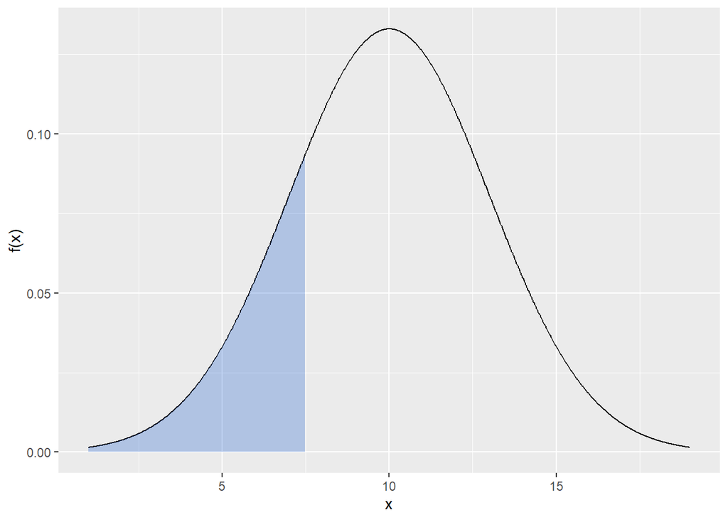

It’s easy with `pnorm()`:

```r
pnorm(7.5, mean = 10, sd = 3)
```

```
## [1] 0.2023284
```

We have around a 20% chance to observe a value of 7.5 or less.

- What if we want to know the probability of observing the value of $x$ or *higher*?

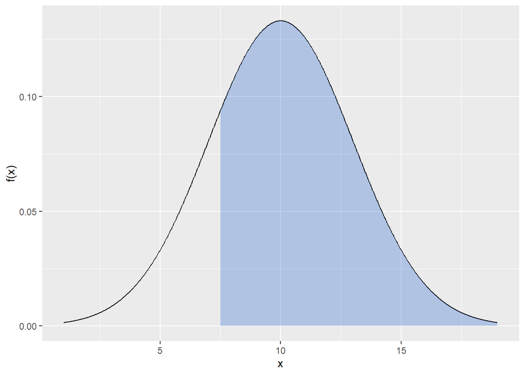

HINT: you could use `pnorm()` and the law of total probability to figure it out!

# Sampling distribution

> Recall that the *sampling distribution* describes the distribution of a *sample statistic*.

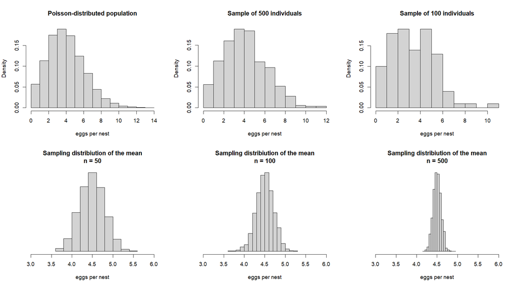

- Do you remember the two main factors that determine the width of a sampling distribution?

## Central limit theorem and the sampling distribution

Navigate to the [probability theory](https://seeing-theory.brown.edu/probability-distributions/index.html) page on Seeing Theory.

Follow the link to the **Central Limit Theorem** section.

This demo samples values from the **beta distribution**, a two-parameter continuous distribution with a bounded domain from 0 to 1.

- Adjust the sliders to see how the two parameters affect the distribution’s shape.

Try sampling with different numbers of draws and samples.

# Questions

## Q 1: Binomial Probability 1

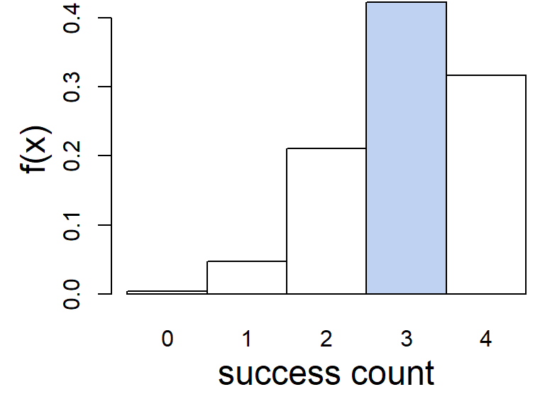

Binomial Probabiltiy Mass Function

- **Q1 (2 pts.):** What is the probability of observing a count of *exactly* 3 successes in a binomial distribution with parameters n = 4 and p = 0.75?
  - Include your answer and the R code you used to find it.
  - Note: To receive full credit, you cannot use `lower.tail = FALSE` in your code.

## Q 2: Binomial Probability 2

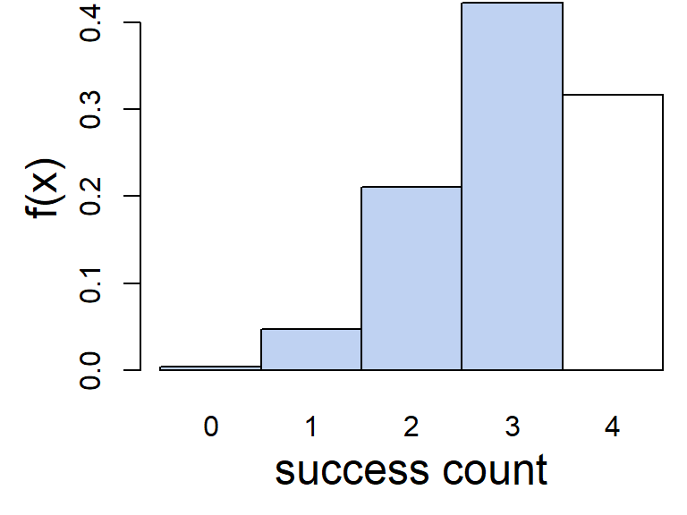

Binomial Probabiltiy Mass Function

- **Q2 (2 pts.):** What is the probability of observing a count of 3 successes *or fewer* in a binomial distribution with parameters n = 4 and p = 0.75?
  - Include your answer and the R code you used to find it.
  - Note: To receive full credit, you cannot use `lower.tail = FALSE` in your code.

## Q 3: Binomial Probability 3

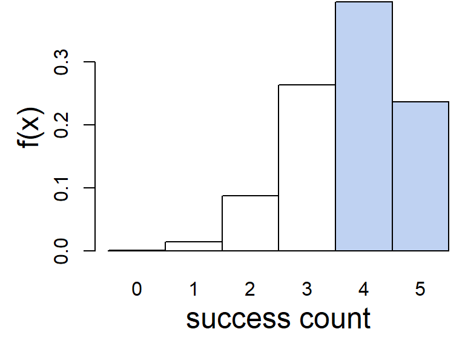

Binomial Probabiltiy Mass Function

- **Q3 (2 pts.):** What is the probability of observing *more than* 3 successes in a binomial distribution with parameters n = **5** and p = 0.75?
  - Include your answer and the R code you used to find it.
  - Note: To receive full credit, you cannot use `lower.tail = FALSE` in your code.

## Q 4: Normal Probability 1

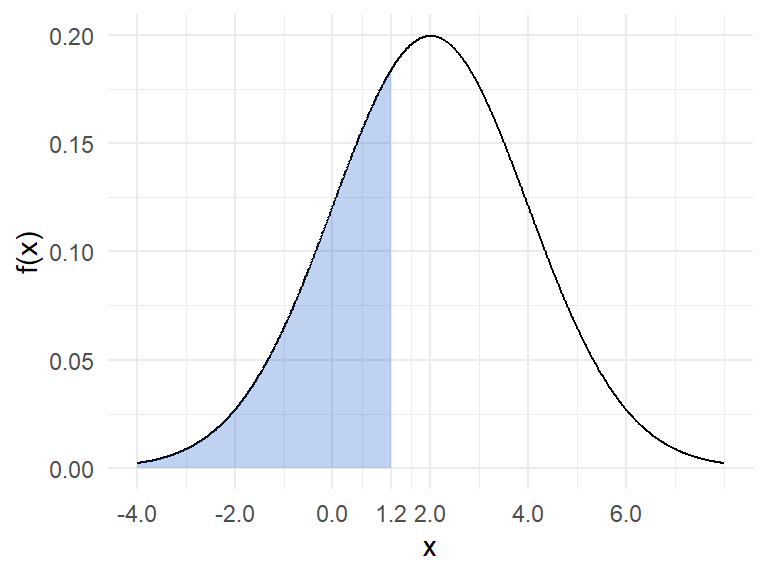

Normal Distribution - Probability Density Function

- **Q4 (2 pts.):** - What is the probability of observing a value of *less than* 1.2 from a normally-distributed population with mean = 2 and standard deviation = 2?
  - Include your answer and the R code you used to find it.
  - Note: To receive full credit, you cannot use `lower.tail = FALSE` in your code.

## Q 5: Normal Probability 2

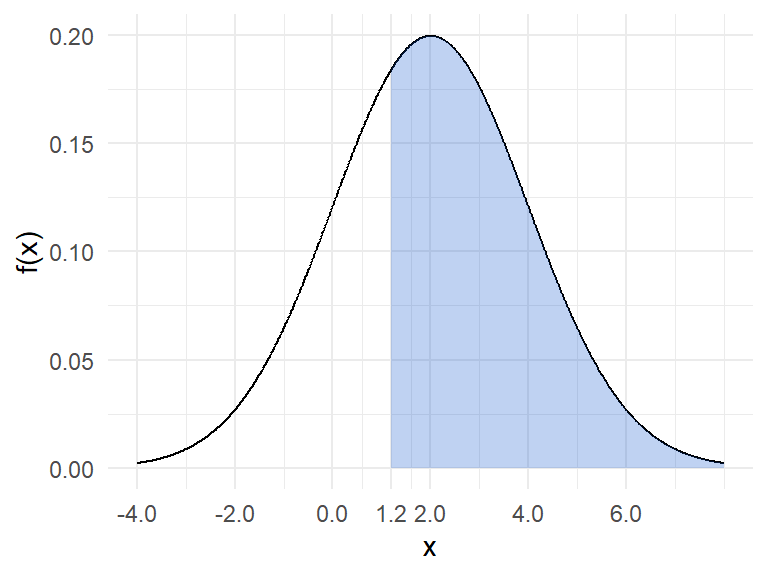

Normal Distribution - Probability Density Function

- **Q5 (2 pts.):** - What is the probability of observing a value of *greater than* 1.2 from a normally-distributed population with mean = 2 and standard deviation = 2?
  - Include your answer and the R code you used to find it.
  - Note: To receive full credit, you cannot use `lower.tail = FALSE` in your code.

## Q 6: Normal Probability 3

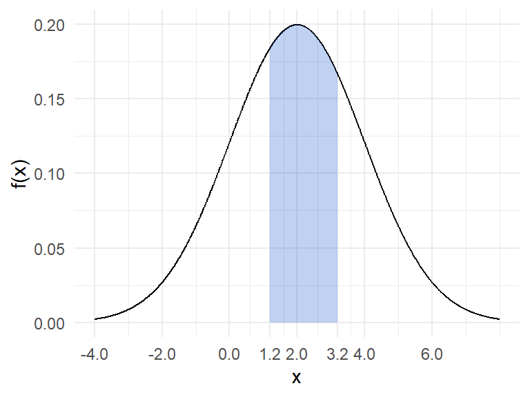

Normal Distribution - Probability Density Function

- **Q6 (4 pts.):** - What is the probability of observing a value *between* 1.2 and 3.2 from a normally-distributed population with mean = 2 and standard deviation = 2?
  - Include both your answer and the R code you used.
  - Note: To receive full credit, you cannot use `lower.tail = FALSE` in your code.

## Q 7: Central Limit Theorem 1

- **Central Limit Theorem**

Navigate to the [probability theory](https://seeing-theory.brown.edu/probability-distributions/index.html) page on Seeing Theory.

Follow the link to the **Central Limit Theorem** section.

- **Sampling Distribution**
1. Choose a set of $\alpha$ and $\beta$ parameters that result in a skewed beta distribution.
2. Set the **sample size** to 1 and the **draws** to 50.
3. Hit the sample button several times and observe the evolution of the histogram.
- **Q7 (2 pts.):** Describe how the shape of the histogram changes as you continue to press the *sample* button.

## Q 8: Central Limit Theorem 2

- **Sampling Distribution**
1. Choose a set of $\alpha$ and $\beta$ parameters that result in a skewed beta distribution.
2. Set the **sample size** to **2** and the **draws** to 50.
3. Hit the sample button several times and observe the evolution of the histogram.
- **Q8 (2 pts.):** Describe how the shape of the histogram changes as you continue to press the *sample* button.

## Q 9-11: Central Limit Theorem 3

- **Sampling Distribution**
1. Choose a set of $\alpha$ and $\beta$ parameters that result in a skewed beta distribution.
2. Set the **sample size** to **15** and the **draws** to 50.
3. Hit the sample button several times and observe the evolution of the histogram.
- **Q9 (2 pts.):** Describe how the shape of the histogram changes as you continue to press the *sample* button.
- **Q10 (2 pts.):** Why is there such a drastic change in the shape of the sampling distribution when you change the sample size from 1 to 2?
- **Q11 (2 pts.):** What are the two main factors that determine the width of the sampling distribution of the mean?

## Q 12: Library of Babel 1

> “Those examples allowed a librarian of genius to discover the fundamental law of the Library. This philosopher observed that all books, however different from one another they might be, consist of identical elements: the space, the period, the comma, and the twenty-two letters of the alphabet. …”

A set of 25 characters doesn’t seem unmanageable.

> “He also posited a fact which all travelers have since confirmed: In all the Library, there are no two identical books. From those incontrovertible premises, the librarian deduced that the Library is”total“-perfect, complete, and whole-and that its bookshelves contain all possible combinations of the twenty-two orthographic symbols (a number which, though unimaginably vast, is not infinite)-that is, all that is able to be expressed, in every language. …”

That sounds like a permutations/combinations problem.

There are $25$ possible words consisting of a single character in the Library. There are $25 \times 25 = 25^2 = 625$ possible 2-character words.

- **Q12 (2 pts.):** How many 3-character words are possible?

## Q 13: Library of Babel 2

Given the properties of the books in the Library:

- 410 pages
- 40 rows per page
- 80 positions per row

There are $410 \times 40 \times 80 = 1,312,000$ positions for characters in each book.

Since there are 25 characters in the Library’s character set, there are a total of $25 ^ {1,312,000}$ possible books.

That’s a very large number. It’s about $2 \times 10^{1,834,097}$. Imagine a 2 followed by almost 2 million zeroes! It certainly wouldn’t fit on Earth.

That’s such a large number that it’s easier to just think of it in symbols. Let’s define the variable $B$ as the number of books in the Library of Babel.

- **Q13 (2 pts.):** How many books would the Library contain if you added *one* additional position to the book size? Express your answer in terms of $B$.